# DZHW Science Survey Dashboard

Tcypina, A. for the Project together with Hartstein, J. & Fabian, G.

# R Shiny dashboard: dynamic visualization of data from DZHW Science Survey

## Step 0: load packages, set working directory and color scheme, load prepared data in form of a frequency table, and create subsets of data for each research field.

### The prepared data set includes 25 lines. There are frequencies for each of research fields by answer categories.

```r
str(data)
```

```
## tibble [25 × 13] (S3: tbl_df/tbl/data.frame)
##  $ Research_field                                 : chr [1:25] "Humanities" "Humanities" "Humanities" "Humanities" ...
##  $ Answer_category                                : chr [1:25] "a" "b" "c" "d" ...
##  $ Research_is_internationally                    : num [1:25] 2.83 12.33 32.34 36.69 15.81 ...
##  $ Influence_of_academic_policy                   : num [1:25] 4.69 10.2 47.2 26.17 11.73 ...
##  $ Requirements_generated_by_evaluations          : num [1:25] 2.28 7.5 52.9 30.2 7.12 ...
##  $ Effort_for_funding_applying                    : num [1:25] 1.94 2.27 18.69 36.89 40.21 ...
##  $ Competition_between_colleagues                 : num [1:25] 0.88 5.18 20.93 34.94 38.07 ...
##  $ Necessity_of_acquiring_funding                 : num [1:25] 0.83 4.08 19.73 38.78 36.58 ...
##  $ The_pressure_to_publish                        : num [1:25] 1.3 4.46 34.2 40.24 19.8 ...
##  $ Funding_opportunities                          : num [1:25] 15.81 33.15 32.62 15.2 3.22 ...
##  $ Cooperation_with_industry                      : num [1:25] 45.1 26.6 25.8 1.9 0.7 ...
##  $ Difficulty_of_appointment_to_post-doc_positions: num [1:25] 20.1 13.8 21.7 26.3 18.1 ...
##  $ Reliability_of_the_scientific_results          : num [1:25] 3.51 10.33 18.7 43.7 23.76 ...
```

# Shiny Dashboard

## In a Shiny R Dashboard code, there are typically three fundamental elements.

## Step 1: create and fill dashboard.

### User interface (UI): this part of the code defines the layout and appearance of the dashboard. It specifies how the dashboard will look to the user, including the arrangement of widgets such as buttons or sliders, and the overall structure of the interface.

The following code defines the interface structure: the dashboard page has the header, the sidebar with the option to choose between data or diagrams by research fields, and the body.

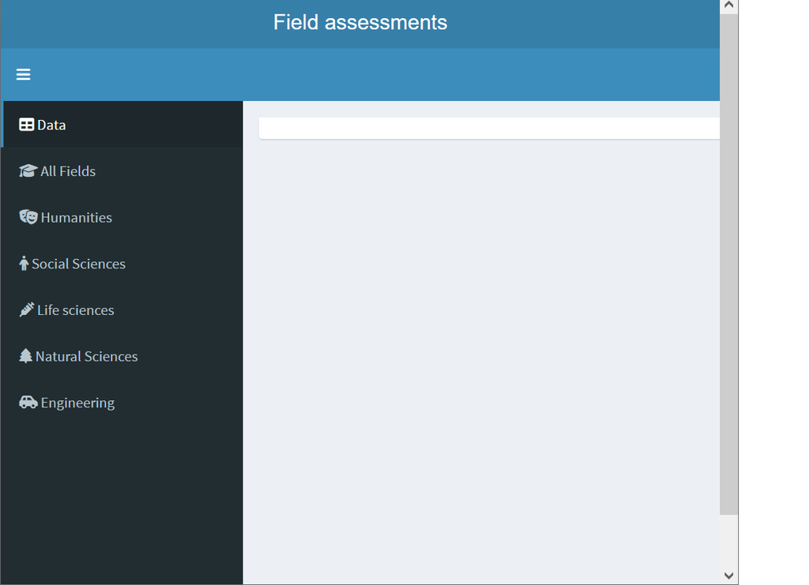

Interface Structure

```r
# create and fill dashboard
ui <- dashboardPage(
  dashboardHeader(title = "Field assessments"),
  dashboardSidebar(
    sidebarMenu(
      menuItem("Data", tabName = "datatable", icon = icon("table", lib = "font-awesome")),
      menuItem("All Fields", tabName = "all", icon = icon("graduation-cap", lib = "font-awesome")),
      menuItem("Humanities", tabName = "field1", icon = icon("masks-theater", lib = "font-awesome")),
      menuItem("Social Sciences", tabName = "field2", icon = icon("person", lib = "font-awesome")),
      menuItem("Life sciences", tabName = "field3", icon = icon("syringe", lib = "font-awesome")),
      menuItem("Natural Sciences", tabName = "field4", icon = icon("tree", lib = "font-awesome")),
      menuItem("Engineering", tabName = "field5", icon = icon("car-side", lib = "font-awesome"))
    )
  ),
  dashboardBody(
    tabItems(
      # first tabItem
      tabItem(tabName = "datatable",
              tabBox(id="t1", width = 20,
                     tabPanel("Data", dataTableOutput("data_output"), icon = icon("table"))
              )

      )
```

## Step 2: create server function.

### Server Logic: The server logic is where you define the behaviour and functionality of your dashboard. This part of the R code contains functions and operations that react to user inputs from the UI. It processes data, performs calculations and updates the UI dynamically based on user actions.

This particular piece of the code is responsible for output of the data table and creation of diagrams based on the data for all research fields.

```r
# create server function
 server <- function(input, output, session){
#Output data
    output$data_output <- renderDataTable(data,options = list(
     pageLength = 10, autoWidth = TRUE,
     scrollX = TRUE
   ))

# Output all Fields
   output$fa_block <- renderPlot({
     ggplot(data,aes(Research_field,.data[[input$features]], fill = Answer_category))+
       geom_bar(stat="identity",position="dodge")
```

### The hidden R code looks similar, it creates other graphs by use of one of two R-packages: ggplot2 and plotly. The following pictures show examples of such graphics.

### Example 1 - Barchart, based on the data for all fields

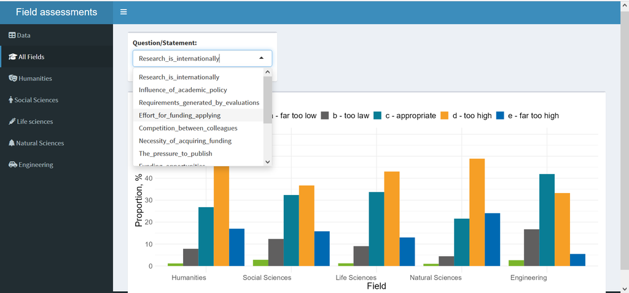

### Example 2 - 2D Scatterplot, based on the data of Social Scientists

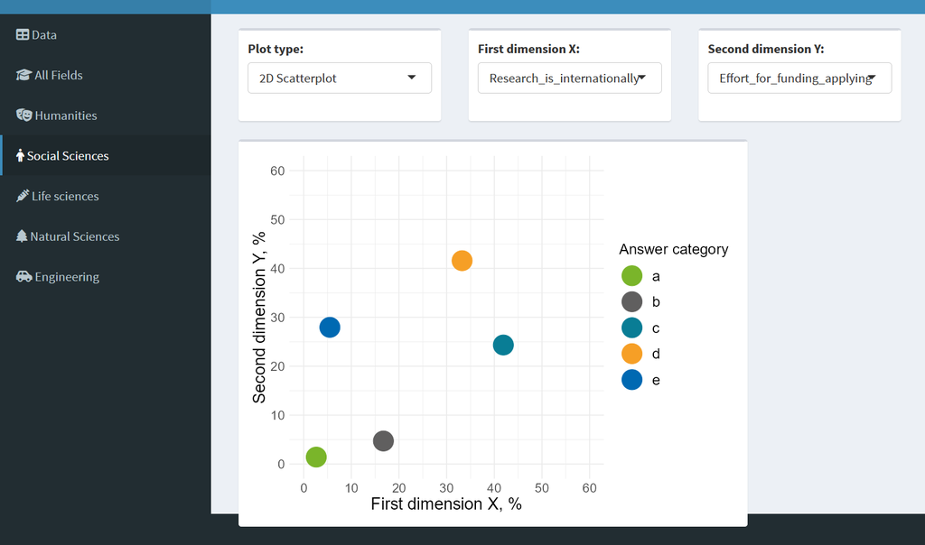

### Example 3 - 3D Bubbleplot, based on the data of Natural Scientists

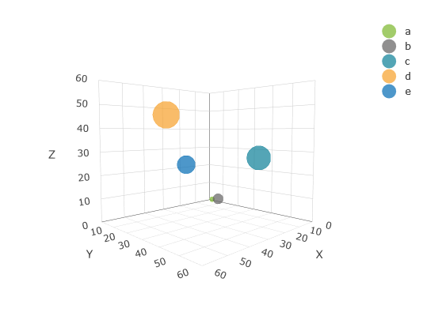

## Step 3: call dashboard.

### Running the Shiny app: use attached full version of R-code (paths are redacted and must be filled by you) to run the Dashboard and to use it dynamically.

```r
# call dashboard
shinyApp(ui=ui, server=server)
```